# Introduction to Probability and Data

Tamal Mukherjee

to view http://htmlpreview.github.io To run r code **shortcut is ctrl+alt+i**

# Introduction

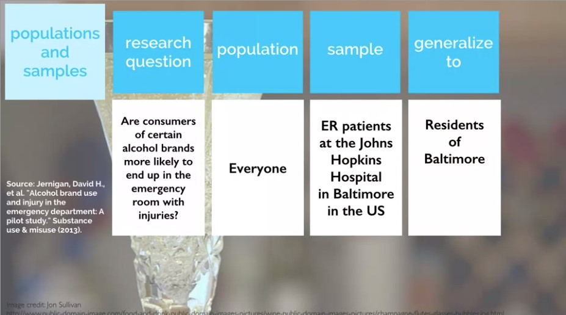

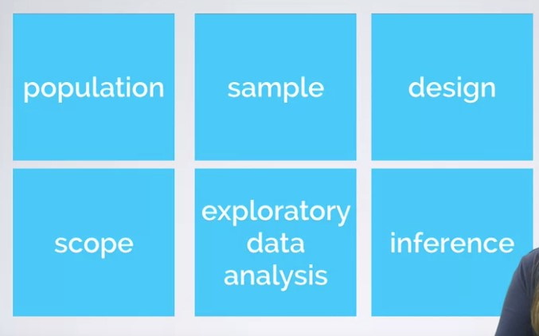

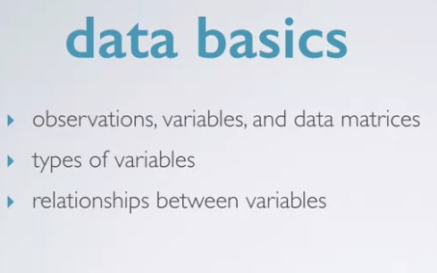

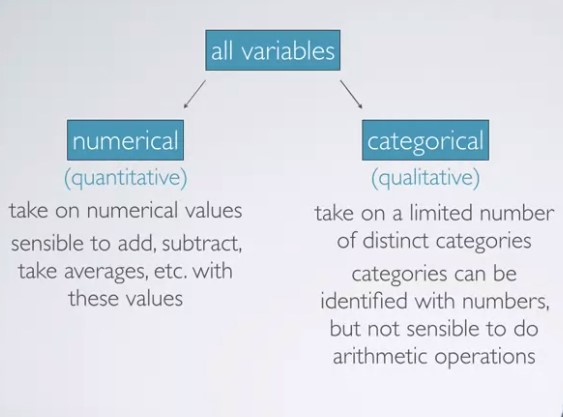

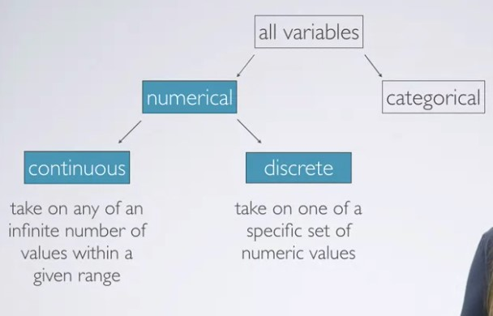

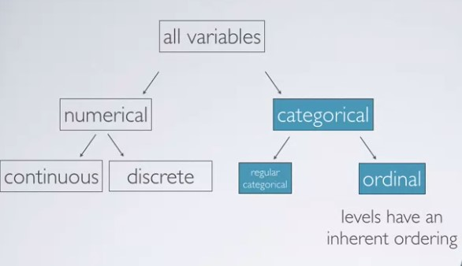

**discrete numerical variable**: An accounted veriable that can only take on whole number values

**continuous numerical variable**: it can take on any number of values between two set of numbers

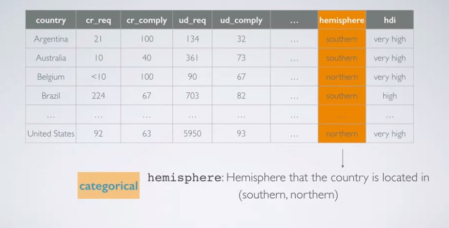

*hdi* is an **ordinal categorical variable**

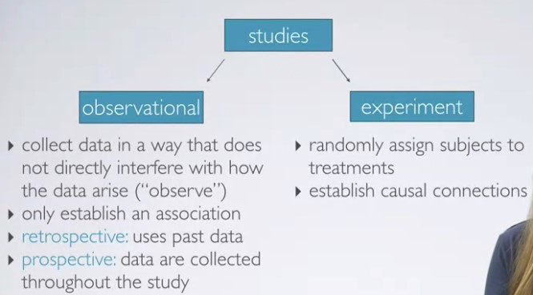

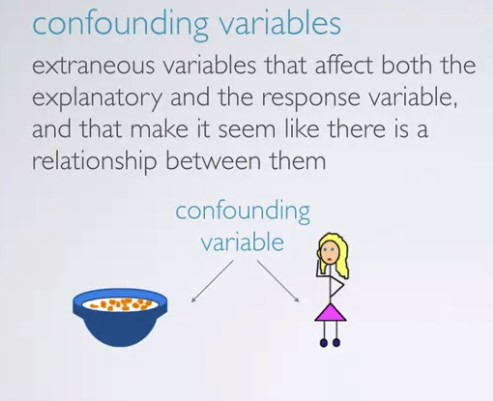

[figure not shown]

# Sampling & sources of bias

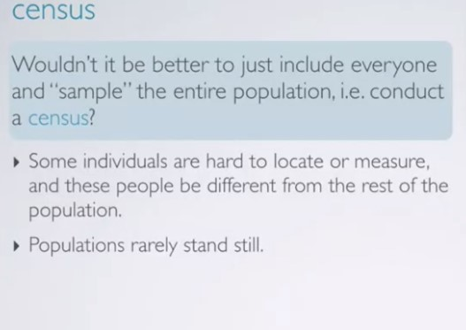

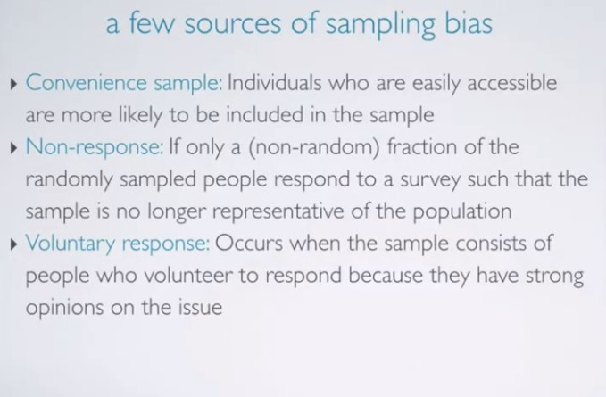

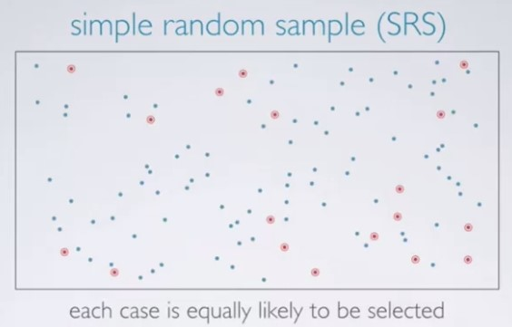

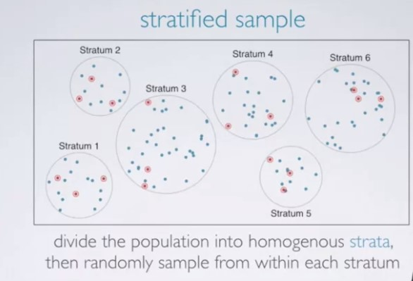

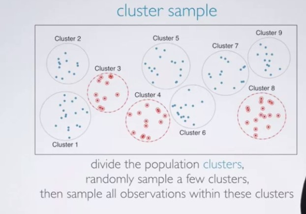

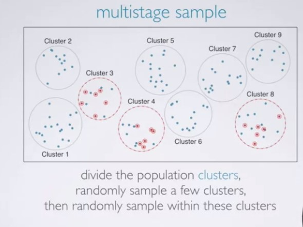

# Experimental Design

Principles of experimental design

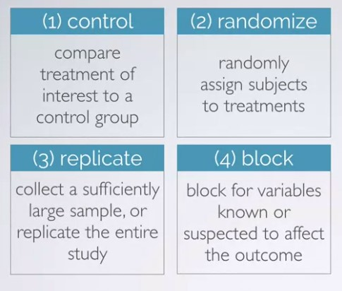

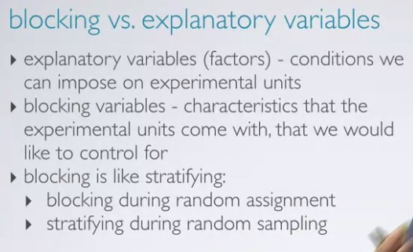

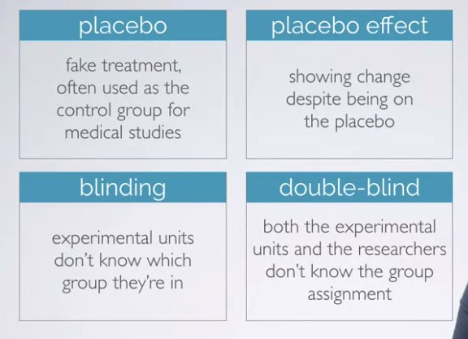

# Random Sample Assignment

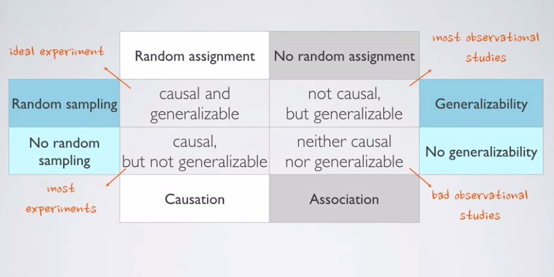

**quiz**

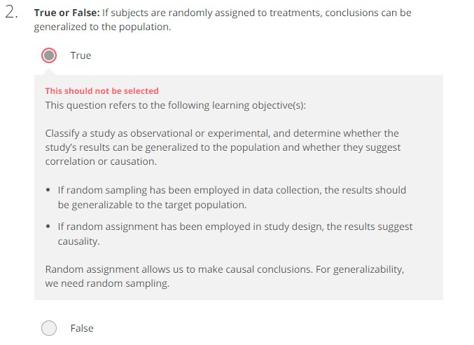

**Shortcuts**

piping operator: ctrl + shift + m

assign operator: alt + -

# Assignment

```r
library(dplyr)
library(ggplot2)
library(statsr)
```

```r
data(arbuthnot)
dim(arbuthnot)
```

```
[1] 82  3
```

```r
names(arbuthnot)
```

```
[1] "year"  "boys"  "girls"
```

```r
arbuthnot$boys
```

```
 [1] 5218 4858 4422 4994 5158 5035 5106 4917 4703 5359 5366 5518 5470 5460 4793 4107 4047 3768 3796 3363 3079 2890 3231 3220
[25] 3196 3441 3655 3668 3396 3157 3209 3724 4748 5216 5411 6041 5114 4678 5616 6073 6506 6278 6449 6443 6073 6113 6058 6552
[49] 6423 6568 6247 6548 6822 6909 7577 7575 7484 7575 7737 7487 7604 7909 7662 7602 7676 6985 7263 7632 8062 8426 7911 7578
[73] 8102 8031 7765 6113 8366 7952 8379 8239 7840 7640
```

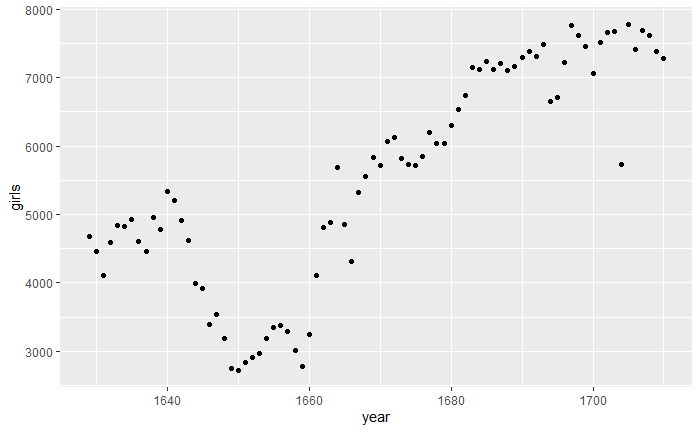

```r
ggplot(data = arbuthnot, aes(x = year, y = girls)) +
  geom_point()
```

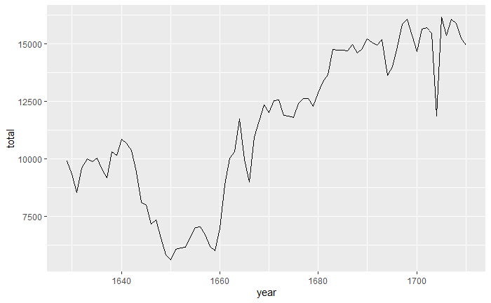

```r
arbuthnot <- arbuthnot %>%
  mutate(total = boys + girls)
ggplot(data = arbuthnot, aes(x = year, y = total)) +
  geom_line()
```

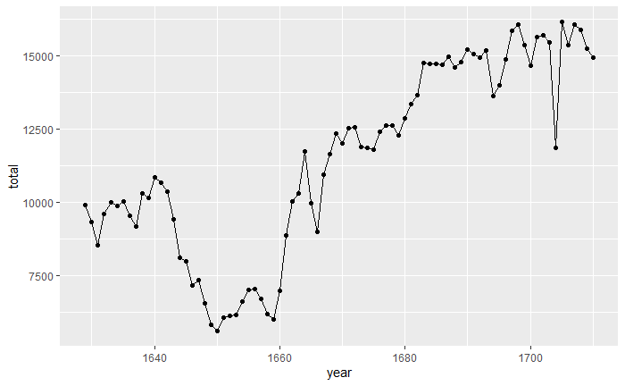

```r
ggplot(data = arbuthnot, aes(x = year, y = total)) +
  geom_line() +
  geom_point()
```

```r
arbuthnot <- arbuthnot %>%
  mutate(more_boys = boys > girls)
```

```r
dim(present)
```

```
[1] 74  5
```

Calculate the total number of births for each year and store these values in a new variable called total in the present dataset. Then, calculate the proportion of boys born each year and store these values in a new variable called prop_boys in the same dataset. Plot these values over time and based on the plot determine if the following statement is true or false: The proportion of boys born in the US has decreased over time.

True

False

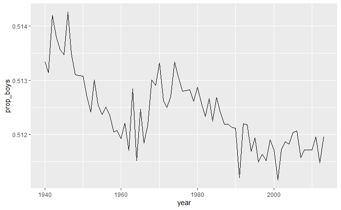

Create a new variable called more_boys which contains the value of either TRUE if that year had more boys than girls, or FALSE if that year did not. Based on this variable which of the following statements is true?

Every year there are more girls born than boys.

Every year there are more boys born than girls.

Half of the years there are more boys born, and the other half more girls born.

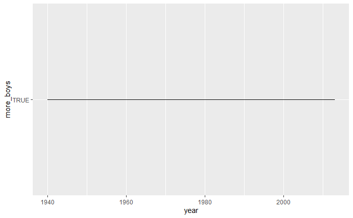

Calculate the boy-to-girl ratio each year, and store these values in a new variable called prop_boy_girl in the present dataset. Plot these values over time. Which of the following best describes the trend?

There appears to be no trend in the boy-to-girl ratio from 1940 to 2013.

There is initially an increase in boy-to-girl ratio, which peaks around 1960. After 1960 there is a decrease in the boy-to-girl ratio, but the number begins to increase in the mid 1970s.

There is initially a decrease in the boy-to-girl ratio, and then an increase between 1960 and 1970, followed by a decrease. The boy-to-girl ratio has increased over time.

There is an initial decrease in the boy-to-girl ratio born but this number appears to level around 1960 and remain constant since then.

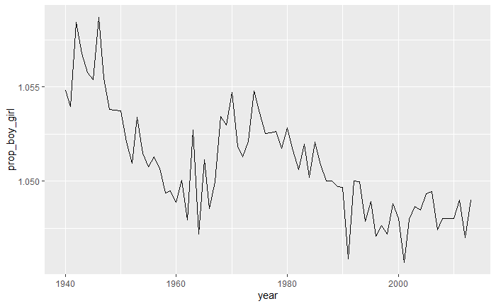